# European Union (EU) Aid in Russia-Ukraine Conflict

Abstract

An analysis on the commitment and allocation of humanitarian aid from EU countries

# Allocations

- The figure below represents the humanitarian allocations from EU countries. We find that Estonia and France are the only countries that significantly allocated humanitarian aid to its budget
- Italy, Sweeden and Bulguria have also allocated some budget for aid
- Germany, Croatia, Netherlands, Poland, Slovakia have all allocated almost no aid to its budget

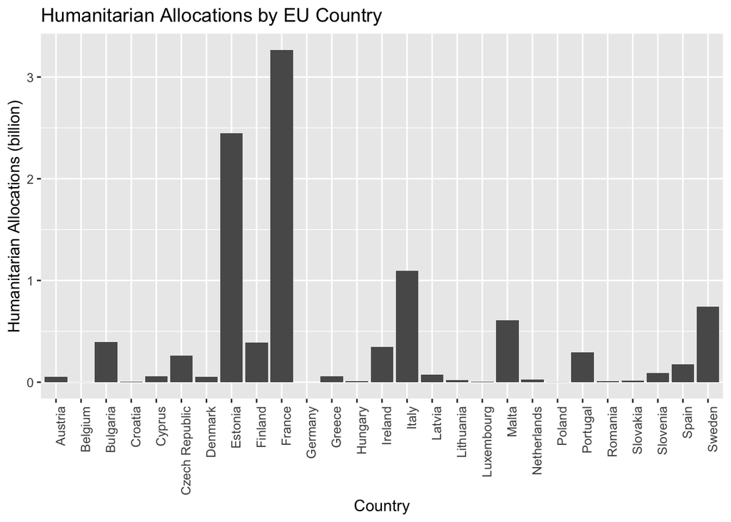

# Commitment

- This figure shows the commitment (promise) that EU countries have to allocate humunaitarian aid.
- Germany, Netherlands and Poland are notable countries who have committed in providing the most aid

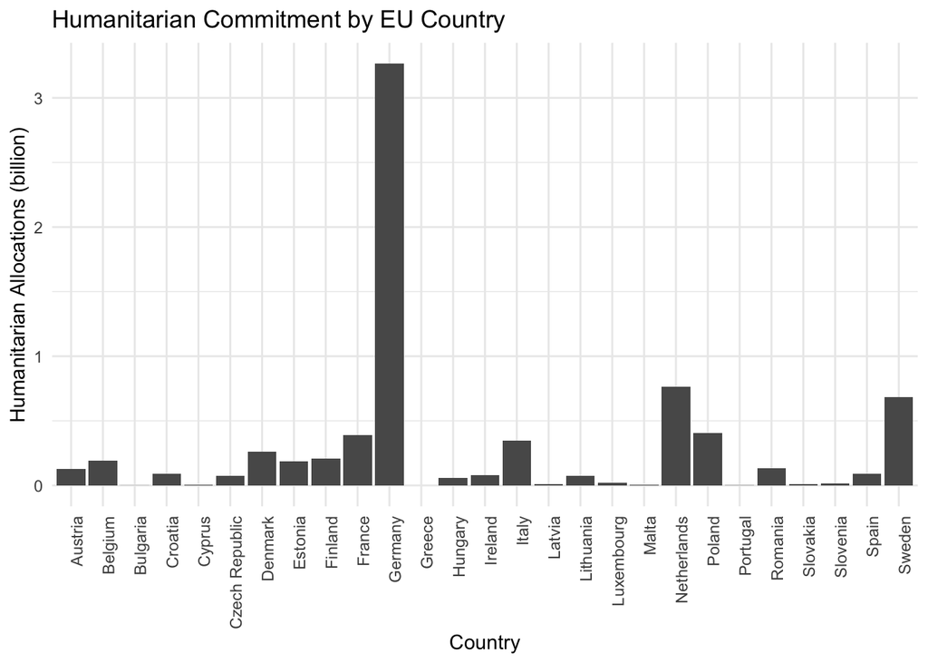

# Allocation vs Commitment

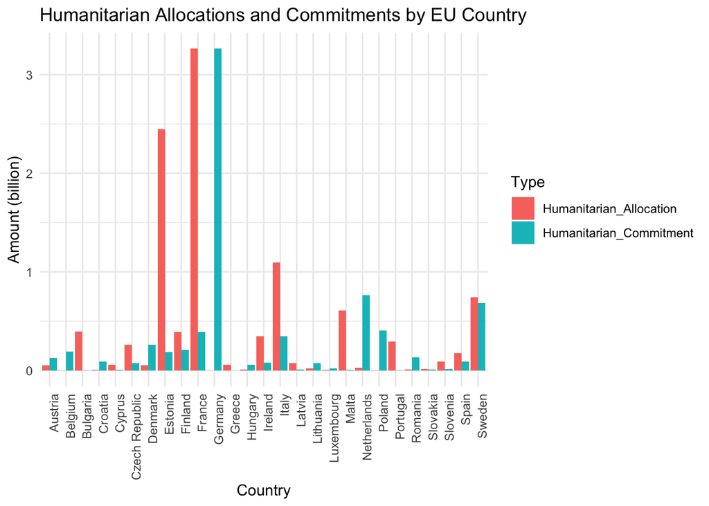

# Other Talking Points

- A figure was not constructed but we can also compare how much spending is dedicated towards the country’s military.
- We can compare if this exceeds the allocated humanitarian aid.
- This will also help us understand the commitment or weight of importance that EU countries place on the conflict
- Russia is also a huge contributor of fossil fuels to countries in the EU. This would definitely cause indecision with regards to supporting Ukraine. The governments of these EU countries do not want to risk a cut in their energy supply
- As a result, some EU countries are conflicted in taking a firm stance in the war.